# Ford GoBike System Data

## Preliminary Wrangling

This document explores a dataset containing information about individual rides made in a bike-sharing system covering the greater San Francisco Bay area in half late year of 2017 for approximately 520,000 attemps.

```python
# import all packages and set plots to be embedded inline
import numpy as np
import pandas as pd
import matplotlib.pyplot as plt
import seaborn as sb
import geopy.distance

%matplotlib inline
```

```python
df = pd.read_csv('2017-fordgobike-tripdata.csv')
```

```python
df.sample(5)
```

|  | duration_sec | start_time | end_time | start_station_id | start_station_name | start_station_latitude | start_station_longitude | end_station_id | end_station_name | end_station_latitude | end_station_longitude | bike_id | user_type | member_birth_year | member_gender |
| --- | --- | --- | --- | --- | --- | --- | --- | --- | --- | --- | --- | --- | --- | --- | --- |
| 275321 | 844 | 2017-10-05 08:39:44.2230 | 2017-10-05 08:53:48.8910 | 16 | Steuart St at Market St | 37.794130 | -122.394430 | 80 | Townsend St at 5th St | 37.775306 | -122.397380 | 46 | Subscriber | 1969.0 | Male |
| 149953 | 1003 | 2017-11-09 17:24:28.8160 | 2017-11-09 17:41:12.1280 | 64 | 5th St at Brannan St | 37.776754 | -122.399018 | 17 | Embarcadero BART Station (Beale St at Market St) | 37.792251 | -122.397086 | 856 | Subscriber | 1984.0 | Male |
| 240190 | 876 | 2017-10-16 07:43:35.6060 | 2017-10-16 07:58:12.1800 | 248 | Telegraph Ave at Ashby Ave | 37.855956 | -122.259795 | 167 | College Ave at Harwood Ave | 37.848152 | -122.252160 | 1131 | Subscriber | 1980.0 | Female |
| 180559 | 588 | 2017-11-01 10:52:47.9560 | 2017-11-01 11:02:36.3110 | 36 | Folsom St at 3rd St | 37.783830 | -122.398870 | 16 | Steuart St at Market St | 37.794130 | -122.394430 | 2362 | Subscriber | 1978.0 | Female |
| 319536 | 270 | 2017-09-22 15:24:55.6790 | 2017-09-22 15:29:26.4750 | 89 | Division St at Potrero Ave | 37.769218 | -122.407646 | 80 | Townsend St at 5th St | 37.775306 | -122.397380 | 2972 | Subscriber | 1991.0 | Male |

```python
df.info()
```

```
<class 'pandas.core.frame.DataFrame'>
RangeIndex: 519700 entries, 0 to 519699
Data columns (total 15 columns):
duration_sec               519700 non-null int64
start_time                 519700 non-null object
end_time                   519700 non-null object
start_station_id           519700 non-null int64
start_station_name         519700 non-null object
start_station_latitude     519700 non-null float64
start_station_longitude    519700 non-null float64
end_station_id             519700 non-null int64
end_station_name           519700 non-null object
end_station_latitude       519700 non-null float64
end_station_longitude      519700 non-null float64
bike_id                    519700 non-null int64
user_type                  519700 non-null object
member_birth_year          453159 non-null float64
member_gender              453238 non-null object
dtypes: float64(5), int64(4), object(6)
memory usage: 59.5+ MB
```

```python
df.describe()
```

|  | duration_sec | start_station_id | start_station_latitude | start_station_longitude | end_station_id | end_station_latitude | end_station_longitude | bike_id | member_birth_year |
| --- | --- | --- | --- | --- | --- | --- | --- | --- | --- |
| count | 519700.000000 | 519700.000000 | 519700.000000 | 519700.000000 | 519700.000000 | 519700.000000 | 519700.000000 | 519700.000000 | 453159.000000 |
| mean | 1099.009521 | 95.034245 | 37.771653 | -122.363927 | 92.184041 | 37.771844 | -122.363236 | 1672.533079 | 1980.404787 |
| std | 3444.146451 | 86.083078 | 0.086305 | 0.105573 | 84.969491 | 0.086224 | 0.105122 | 971.356959 | 10.513488 |
| min | 61.000000 | 3.000000 | 37.317298 | -122.444293 | 3.000000 | 37.317298 | -122.444293 | 10.000000 | 1886.000000 |
| 25% | 382.000000 | 24.000000 | 37.773492 | -122.411726 | 23.000000 | 37.774520 | -122.410345 | 787.000000 | 1974.000000 |
| 50% | 596.000000 | 67.000000 | 37.783521 | -122.398870 | 66.000000 | 37.783830 | -122.398525 | 1728.500000 | 1983.000000 |
| 75% | 938.000000 | 139.000000 | 37.795392 | -122.391034 | 134.000000 | 37.795392 | -122.391034 | 2520.000000 | 1988.000000 |
| max | 86369.000000 | 340.000000 | 37.880222 | -121.874119 | 340.000000 | 37.880222 | -121.874119 | 3733.000000 | 1999.000000 |

I want to check any problem of this dataset needed to be clean

```python
df[df.duplicated()]
```

|  | duration_sec | start_time | end_time | start_station_id | start_station_name | start_station_latitude | start_station_longitude | end_station_id | end_station_name | end_station_latitude | end_station_longitude | bike_id | user_type | member_birth_year | member_gender |
| --- | --- | --- | --- | --- | --- | --- | --- | --- | --- | --- | --- | --- | --- | --- | --- |

The start_time, end_time columns have to change to datetime type and member_birth_year column have to change to integer type

```python
df.start_time = pd.to_datetime(df.start_time)
df.end_time = pd.to_datetime(df.end_time)

df.member_birth_year=df.member_birth_year.fillna(0).astype('int')
```

```python
df[df.duration_sec != ((df.end_time - df.start_time).astype('timedelta64[s]'))]
```

|  | duration_sec | start_time | end_time | start_station_id | start_station_name | start_station_latitude | start_station_longitude | end_station_id | end_station_name | end_station_latitude | end_station_longitude | bike_id | user_type | member_birth_year | member_gender |
| --- | --- | --- | --- | --- | --- | --- | --- | --- | --- | --- | --- | --- | --- | --- | --- |
| 166700 | 84640 | 2017-11-04 16:08:38.306 | 2017-11-05 14:39:18.340 | 70 | Central Ave at Fell St | 37.773311 | -122.444293 | 29 | O'Farrell St at Divisadero St | 37.782405 | -122.439446 | 3061 | Customer | 1989 | Male |
| 166867 | 62041 | 2017-11-04 21:36:57.538 | 2017-11-05 13:50:59.355 | 314 | Santa Clara St at Almaden Blvd | 37.333988 | -121.894902 | 282 | Market St at Park St | 37.332426 | -121.890349 | 2891 | Customer | 0 | NaN |
| 167041 | 80721 | 2017-11-04 15:38:37.140 | 2017-11-05 13:03:58.957 | 14 | Clay St at Battery St | 37.795001 | -122.399970 | 66 | 3rd St at Townsend St | 37.778742 | -122.392741 | 1147 | Customer | 0 | NaN |
| 167167 | 74738 | 2017-11-04 16:40:52.734 | 2017-11-05 12:26:31.096 | 52 | McAllister St at Baker St | 37.777416 | -122.441838 | 29 | O'Farrell St at Divisadero St | 37.782405 | -122.439446 | 1106 | Customer | 1992 | Female |
| 167577 | 68144 | 2017-11-04 15:54:56.643 | 2017-11-05 09:50:41.057 | 8 | The Embarcadero at Vallejo St | 37.799953 | -122.398525 | 84 | Duboce Park | 37.769201 | -122.433812 | 3041 | Customer | 0 | NaN |
| 167624 | 58182 | 2017-11-04 18:22:54.984 | 2017-11-05 09:32:37.265 | 177 | MacArthur Blvd at Telegraph Ave | 37.826286 | -122.265100 | 195 | Bay Pl at Vernon St | 37.812314 | -122.260779 | 554 | Customer | 0 | NaN |
| 167634 | 73646 | 2017-11-04 13:59:08.039 | 2017-11-05 09:26:34.047 | 97 | 14th St at Mission St | 37.768265 | -122.420110 | 24 | Spear St at Folsom St | 37.789677 | -122.390428 | 1928 | Customer | 0 | NaN |
| 167647 | 73212 | 2017-11-04 13:58:16.412 | 2017-11-05 09:18:28.858 | 97 | 14th St at Mission St | 37.768265 | -122.420110 | 24 | Spear St at Folsom St | 37.789677 | -122.390428 | 65 | Customer | 0 | NaN |
| 167759 | 51434 | 2017-11-04 18:14:06.949 | 2017-11-05 07:31:21.100 | 181 | Grand Ave at Webster St | 37.811377 | -122.265192 | 197 | El Embarcadero at Grand Ave | 37.808848 | -122.249680 | 518 | Subscriber | 1981 | Other |
| 167801 | 292 | 2017-11-05 01:59:52.216 | 2017-11-05 01:04:45.180 | 121 | Mission Playground | 37.759210 | -122.421339 | 119 | 18th St at Noe St | 37.761047 | -122.432642 | 2773 | Subscriber | 1994 | Male |

These are calculator errors and the row index 167801 has wrong input data with end_time before start_time. I would like to delete these rows.

```python
df= df[~df.duration_sec != ((df.end_time - df.start_time).astype('timedelta64[s]'))]
```

### What is/are the main feature(s) of interest in your dataset?

I'm most interested in figuring out what is behavior of people using GoBike system.

### What features in the dataset do you think will help support your investigation into your feature(s) of interest?

I expect that user gender, type, birth year would be the effect of people using bike: Male users will use Bike more than female users, young people will use bike more, and member (subscribe) users will use bike more than casual (Customer). I also think on weekend, people will use bike more for a trips.

## Univariate Exploration

I'll start by looking at the distribution of time, duration, member birth year variables.

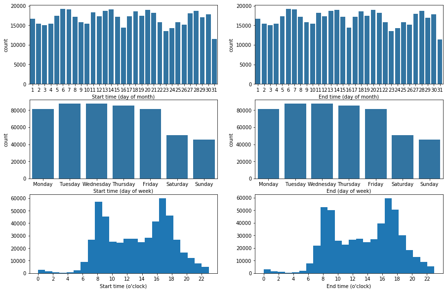

```python
#We creat subplots of histogram for start time and end time depend on time get by day of month, day of week, and hour of day
base_color=sb.color_palette()[0]
plt.figure(figsize=[15,10])

#Subplots for day of month
plt.subplot(3, 2, 1)
sb.countplot(data=df, x=df.start_time.dt.day,color = base_color)
plt.xlabel('Start time (day of month)')

plt.subplot(3, 2, 2)
sb.countplot(data=df, x=df.end_time.dt.day,color = base_color)
plt.xlabel('End time (day of month)')

#Subplots for day of week
ax=plt.subplot(3,2,3)
sb.countplot(data=df, x=df.start_time.dt.weekday,color = base_color)
plt.xticks([0,1,2,3,4,5,6],['Monday','Tuesday','Wednesday','Thursday','Friday','Saturday','Sunday'])
plt.xlabel('Start time (day of week)')

ax=plt.subplot(3,2,4)
sb.countplot(data=df, x=df.end_time.dt.weekday,color = base_color)
plt.xticks([0,1,2,3,4,5,6],['Monday','Tuesday','Wednesday','Thursday','Friday','Saturday','Sunday'])
plt.xlabel('End (day of week)')

#Subplots for hour of day
ax=plt.subplot(3,2,5)
plt.hist(df.start_time.dt.hour,bins = 24)
plt.xticks([0,2,4,6,8,10,12,14,16,18,20,22])
plt.xlabel('Start time (o\'clock)');

ax=plt.subplot(3,2,6)
plt.hist(df.end_time.dt.hour,bins = 24)
plt.xticks([0,2,4,6,8,10,12,14,16,18,20,22])
plt.xlabel('End time (o\'clock)');
```

It seems like start time and end time have similar trend. People tend to use bike more on weekday rather than weekend and in particular 8am and 5pm. Therefore, we can say, people mostly use bike to go to work and come back.

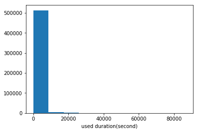

```python
#Now we creat a histogram for used duration
plt.hist(df.duration_sec)
plt.xlabel('used duration(second)');
```

Our histogram is very high skewed to the right. I want to change to logarithsm scale

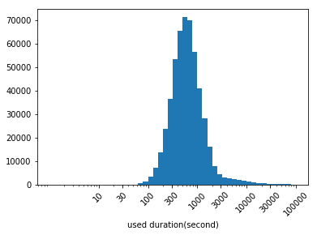

```python
bin_du=10**np.arange(0,5+0.1,0.1)
plt.hist(df.duration_sec, bins = bin_du)
xtick=(10,30,100,300,1000,3000,10000,30000,100000)
xlabel=['{}'.format(x) for x in xtick]
plt.xscale('log')
plt.xticks(xtick, labels=xlabel, rotation = 45)
plt.xlabel('used duration(second)');
```

This log histogram is quite normal distribution.

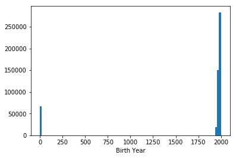

```python
# We will look at the year of birth variable.
plt.hist(df.member_birth_year, bins = 100)
plt.xlabel('Birth Year');
```

It is quite unexplanable to have the age under 1900 and still use bike. I want to point out is any usual in this.

```python
df.query('member_birth_year < 1900 & member_birth_year != 0')
```

|  | duration_sec | start_time | end_time | start_station_id | start_station_name | start_station_latitude | start_station_longitude | end_station_id | end_station_name | end_station_latitude | end_station_longitude | bike_id | user_type | member_birth_year | member_gender |
| --- | --- | --- | --- | --- | --- | --- | --- | --- | --- | --- | --- | --- | --- | --- | --- |
| 425817 | 2546 | 2017-08-19 17:47:32.110 | 2017-08-19 18:29:58.825 | 197 | El Embarcadero at Grand Ave | 37.808848 | -122.24968 | 172 | College Ave at Taft Ave | 37.841800 | -122.251535 | 1448 | Customer | 1886 | Male |
| 426608 | 1767 | 2017-08-19 13:20:02.170 | 2017-08-19 13:49:29.735 | 235 | Union St at 10th St | 37.807239 | -122.28937 | 197 | El Embarcadero at Grand Ave | 37.808848 | -122.249680 | 91 | Customer | 1886 | Male |

It must be typo error, 1886 should be 1986 in member_birth_year. I will replace it

```python
df.member_birth_year= df.member_birth_year.apply(lambda x : 1986 if x == 1886 else x)
```

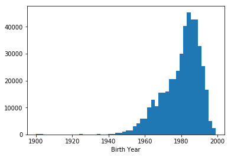

```python
# Creat a sub dataset which excludes member birth year smaller than 1900
df_year= df[df.member_birth_year >= 1900]

plt.hist(df_year.member_birth_year, bins = 50)
plt.xlabel('Birth Year');
```

Member birth year histogram appears as a left skewed distribution having major customer having birth year around 1980 to 1990.

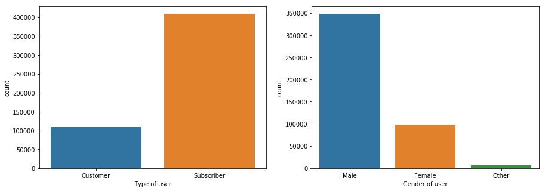

```python
#Creat bar plot for user type and gender of customer.
plt.figure(figsize= [15,5])

plt.subplot(1,2,1)
sb.countplot(data=df, x= 'user_type')
plt.xlabel('Type of user')

plt.subplot(1,2,2)
sb.countplot(data=df, x = 'member_gender')
plt.xlabel('Gender of user');
```

As expected, member user and male user have larger proportion than casual and femal user.

I want to creat a distance column which calculates distance from start station to end station by latitude and longtitude

```python
df['distance']=df.apply(lambda x: geopy.distance.distance((x[5],x[6]),(x[9],x[10])).km,axis=1)
```

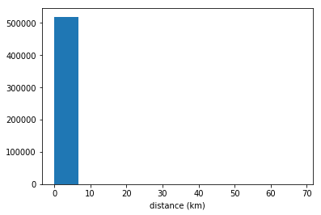

```python
#Creat histogram for distance
plt.hist(df.distance)
plt.xlabel('distance (km)');
```

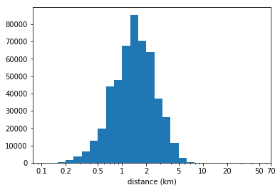

```python
#Change scale to logarithsm
bins_dis=10**np.arange(-1,1.2 + 1/10,1/10)
plt.hist(df.distance, bins = bins_dis)
tick=[0.1,0.2,0.5,1,2,5,10,20,50,70]
labels=('{}'.format(x) for x in tick)
plt.xscale('log')
plt.xticks(tick, labels)
plt.xlabel('distance (km)');
```

Distance histogram appears as a log normal distribution with the mean around 1-2 km.

### Discuss the distribution(s) of your variable(s) of interest. Were there any unusual points? Did you need to perform any transformations?

The distance and duration variable is normal distribution after using log transform. In time variable, data shows that people mostly use bike on weekday at 8am and 5pm as the starting and ending of working time.

### Of the features you investigated, were there any unusual distributions? Did you perform any operations on the data to tidy, adjust, or change the form of the data? If so, why did you do this?

When investigating the member_birth_year, there is a smmall number of typo error.

## Bivariate Exploration

To start off with, I want to look at the pairwise correlations present between numeric variables in the data.

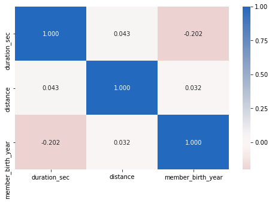

```python
numeric_vars = ['duration_sec', 'distance', 'member_birth_year']
plt.figure(figsize = [8, 5])
sb.heatmap(df[numeric_vars].corr(), annot = True, fmt = '.3f',
           cmap = 'vlag_r', center = 0)
plt.show()
```

Unexpectly, duration and distance doesn't have strong correlated relationship, neither member birth year. I won't perform any further analyses with these variables since they don't look like they'll be of much further interest.

Let's move on to looking at these numeric variables correlate with the categorical variables.

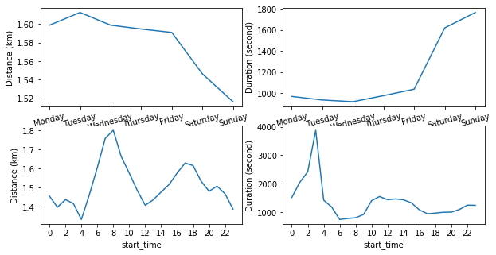

```python
#We will look at how distance and duration correlates with start_time variable.
plt.figure(figsize=[5,5])

#Subplot for day in week
plt.subplot(2,2,1)
df.groupby(df.start_time.dt.weekday).distance.mean().plot(kind = 'line', figsize = [10, 5])
plt.xticks([0,1,2,3,4,5,6],['Monday','Tuesday','Wednesday','Thursday','Friday','Saturday','Sunday'],rotation=15)
plt.ylabel('Distance (km)')

plt.subplot(2,2,2)
df.groupby(df.start_time.dt.weekday).duration_sec.mean().plot(kind = 'line', figsize = [10, 5])
plt.xticks([0,1,2,3,4,5,6],['Monday','Tuesday','Wednesday','Thursday','Friday','Saturday','Sunday'],rotation=15)
plt.ylabel('Duration (second)')

#Subplot for hour in day
plt.subplot(2,2,3)
df.groupby(df.start_time.dt.hour).distance.mean().plot(kind = 'line', figsize = [10, 5])
plt.xticks([0,2,4,6,8,10,12,14,16,18,20,22])
plt.ylabel('Distance (km)')

plt.subplot(2,2,4)
df.groupby(df.start_time.dt.hour).duration_sec.mean().plot(kind = 'line', figsize = [10, 5])
plt.xticks([0,2,4,6,8,10,12,14,16,18,20,22])
plt.ylabel('Duration (second)');
```

These plots have shown that distance tend to further on weekday and around 8am and 5pm. However, the duration shows opposite trend, it is longer on weekend and reaches its peak at 3am. Is it true that people use bike to go to work and come back? Let's take a look

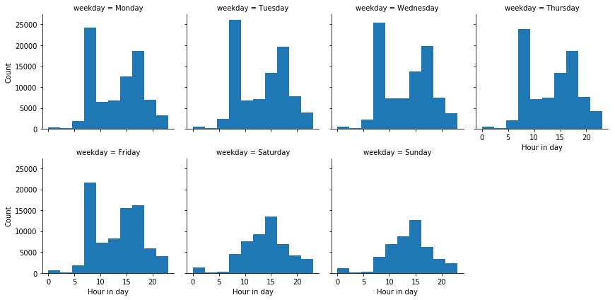

```python
#Creat weekday column to take the value of weekday in start_time
df['weekday']=df.start_time.dt.weekday

#Creat a function to tranform weekday integer value to weekday name string value
def weekday(x):
    number=[0,1,2,3,4,5,6]
    day=['Monday','Tuesday','Wednesday','Thursday','Friday','Saturday','Sunday']
    for idx, val in enumerate(number):
        if x == val:
            return day[idx]

#apply this function
df['weekday']=df.weekday.apply(weekday)

#change weekday to ordered categorical type
week = ['Monday','Tuesday','Wednesday','Thursday','Friday','Saturday','Sunday']
week_order= pd.api.types.CategoricalDtype(ordered = True, categories = week)
df['weekday']=df['weekday'].astype(week_order)

#Create hour column to take the hour in start_time
df['hour']=df.start_time.dt.hour

#plot the histograms
g = sb.FacetGrid(data= df, col = 'weekday', col_wrap = 4)
g.map(plt.hist, 'hour')
g.set_xlabels('Hour in day')
g.set_ylabels('Count');
```

We can see mostly bike used at 8am and 5pm are weekday and on weekend, people use bike around 12-15pm. Now we will se how people goes far by bike these hour and duration that they use bike.

```
c:\program files\python35\lib\site-packages\seaborn\axisgrid.py:715: UserWarning: Using the pointplot function without specifying `order` is likely to produce an incorrect plot.
  warnings.warn(warning)
```

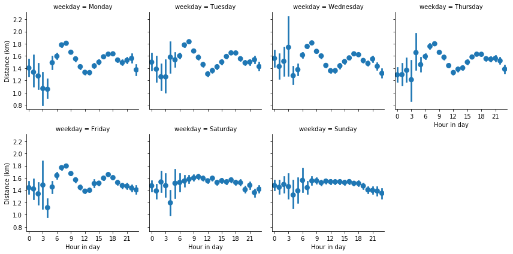

```python
# Creat a facetgrid for distance mean.
g = sb.FacetGrid(data= df, col = 'weekday', col_wrap = 4)
g.map(sb.pointplot,'hour', 'distance', linestyles = '')
g.set(xticks=[0,3,6,9,12,15,18,21],xticklabels = ['0','3','6','9','12','15','18','21'])
g.set_xlabels('Hour in day')
g.set_ylabels('Distance (km)');
```

```
c:\program files\python35\lib\site-packages\seaborn\axisgrid.py:715: UserWarning: Using the pointplot function without specifying `order` is likely to produce an incorrect plot.
  warnings.warn(warning)
```

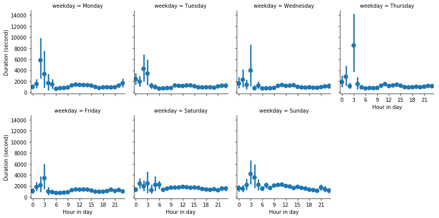

```python
# Create a facetgrid for duration mean
g = sb.FacetGrid(data= df, col = 'weekday', col_wrap = 4)
g.map(sb.pointplot,'hour', 'duration_sec',linestyles = '')
g.set(xticks=[0,3,6,9,12,15,18,21],xticklabels = ['0','3','6','9','12','15','18','21'])
g.set_xlabels('Hour in day')
g.set_ylabels('Duration (second)');
```

The larger error bars afer midnight times are due to there being fewer data at higher duration and lower distance suggest that people do not want to ride bike after midnight or they use bike but ride slowlier. While on weekday, the distance fluctuates hard, getting peak at 8am and 5pm, on weekend, it is quite stable.

We will observate how duration and distance variables correlates with year of birth. However, there are a long range of year, I will make a cut of 10 year since 1900

```python
bin_edges = np.arange(1900, 2010, 10)

#creat distance column for sub dataset df_year
df_year['distance']=df_year.apply(lambda x: geopy.distance.distance((x[5],x[6]),(x[9],x[10])).km,axis=1)

# cluster data as year user born
df_year['year_cut'] = pd.cut(df_year['member_birth_year'], bin_edges, right = False, include_lowest = True,
                  labels = ['00s','10s','20s','30s','40s','50s','60s','70s','80s','90s'])


df_year['year_cut'].value_counts()
```

[output not shown]

```
80s    201068
70s     96122
90s     82088
60s     54674
50s     16024
40s      2438
00s       370
30s       268
20s        95
10s        12
Name: year_cut, dtype: int64
```

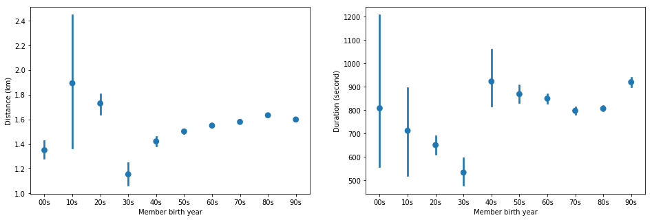

```python
#Creat point plot for year of birth
plt.figure(figsize = [16, 5])
plt.subplot(1,2,1)
sb.pointplot(data = df_year, x = 'year_cut', y = 'distance',linestyles = '', dodge = 0.4)
plt.xlabel('Member birth year')
plt.ylabel('Distance (km)')

plt.subplot(1,2,2)
sb.pointplot(data = df_year, x = 'year_cut', y = 'duration_sec',linestyles = '', dodge = 0.4)
plt.xlabel('Member birth year')
plt.ylabel('Duration (second)');
```

It shows that fewer data at higher duration and lower distance for people were born in 00s to 30s. Young people has higher distance and duration usage.

I want to look more on member birth year relates with time.

```python
#Creat a function to separate birth year as working age
def working_age(x):
    if x in ['00s','10s','20s','30s','40s','50s']:
        return 'retired'
    elif x in ['60s','70s']:
        return 'middle working age'
    else:
        return 'young working age'
```

```python
#Apply this function on sub dataset
df_year['work_age']=df_year['year_cut'].apply(lambda x: working_age(x))
```

```
c:\program files\python35\lib\site-packages\ipykernel_launcher.py:2: SettingWithCopyWarning:
A value is trying to be set on a copy of a slice from a DataFrame.
Try using .loc[row_indexer,col_indexer] = value instead

See the caveats in the documentation: http://pandas.pydata.org/pandas-docs/stable/indexing.html#indexing-view-versus-copy
```

```python
#Creat weekday column to take the value of weekday in start_time
df_year['weekday']=df_year.start_time.dt.weekday

#apply the function used to change weekday number  to string weekday name
df_year['weekday']=df_year.weekday.apply(weekday)

#change weekday to ordered categorical type (created before)
df_year['weekday']=df_year['weekday'].astype(week_order)

#Create hour column to take the hour in start_time
df_year['hour']=df_year.start_time.dt.hour
```

[output not shown]

[output not shown]

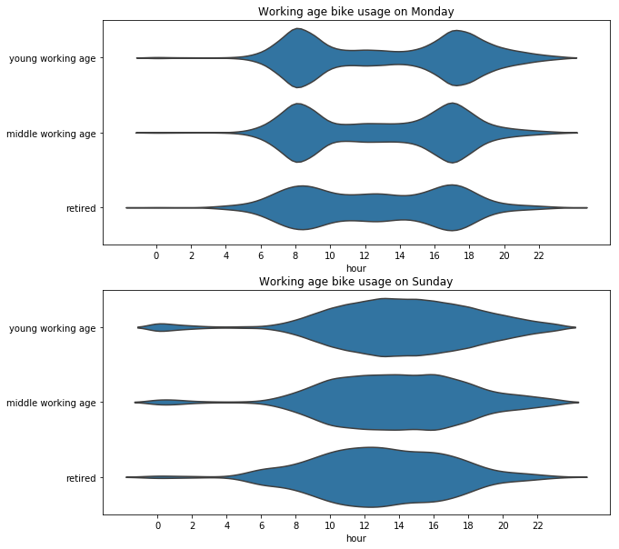

```python
#Creat violin plots for work_age variables on monday as working day and sunday as weekend
plt.figure(figsize=[10,10])

plt.subplot(2,1,1)
sb.violinplot(data = df_year[df['weekday']=='Monday'], x = 'hour', y = 'work_age', color = base_color,
              inner = None)
plt.xticks([0,2,4,6,8,10,12,14,16,18,20,22])
plt.title('Working age bike usage on Monday')
plt.ylabel('')


plt.subplot(2,1,2)
sb.violinplot(data = df_year[df['weekday']=='Sunday'], x = 'hour', y = 'work_age', color = base_color,
              inner = None)
plt.xticks([0,2,4,6,8,10,12,14,16,18,20,22])
plt.title('Working age bike usage on Sunday')
plt.ylabel('');
```

On monday (working day), all type of working age have their data separate on large proportion around 8am and around 5pm. However, retired people still use bike more than others people between these hours.  
On Sunday (weekend), all type of working age have major data from 9am to 6pm. Although retired people tends to wake up earlier and use bike, young working age people stay up late and has a small number of data after 0am,

We move on to categorical variables, user_type and member_gender

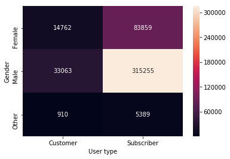

```python
#Creat heatmap for these two categorical variables
ct_counts = df.groupby(['user_type', 'member_gender']).size()
ct_counts = ct_counts.reset_index(name = 'count')
ct_counts = ct_counts.pivot(index = 'member_gender', columns = 'user_type', values = 'count')
sb.heatmap(ct_counts,annot = True, fmt = 'd')
plt.ylabel('Gender')
plt.xlabel('User type');
```

As expected, Male subscriber has large proportion, followed by Female subcriber

### Talk about some of the relationships you observed in this part of the investigation. How did the feature(s) of interest vary with other features in the dataset?

Distance and duration are effected by time variable. On weekday, people mostly use bike for go to work. On weekend, they seem to use bike longer. Male subscriber use bike the most of time

### Did you observe any interesting relationships between the other features (not the main feature(s) of interest)?

Interestingly, 3 numeric variables seem not to have strong correlation and retired people still use bike on starting time and ending time of normal working day on weekday.

## Multivariate Exploration

The main thing I want to explore in this part of the analysis is how people's behavior depends on gender, type and age

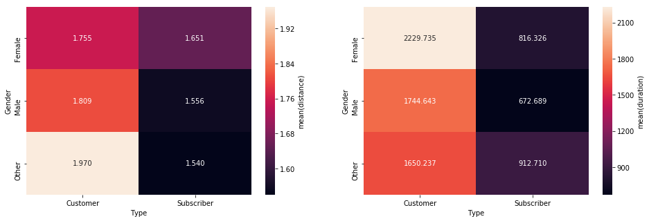

```python
#Creat heatmaps for Gender and Type in distance and duration variables.
plt.figure(figsize=[16,5])

#Heatmap for average distance
plt.subplot(1,2,1)
cat_means = df.groupby(['user_type', 'member_gender']).mean()['distance']
cat_means = cat_means.reset_index(name = 'distance_avg')
cat_means = cat_means.pivot(index = 'member_gender', columns = 'user_type',
                            values = 'distance_avg')
sb.heatmap(cat_means, annot = True, fmt = '.3f',
           cbar_kws = {'label' : 'mean(distance)'})
plt.ylabel('Gender')
plt.xlabel('Type')

#Heatmap for average duration
plt.subplot(1,2,2)
cat_means_du = df.groupby(['user_type', 'member_gender']).mean()['duration_sec']
cat_means_du = cat_means_du.reset_index(name = 'duration_sec_avg')
cat_means_du = cat_means_du.pivot(index = 'member_gender', columns = 'user_type',
                            values = 'duration_sec_avg')
sb.heatmap(cat_means_du, annot = True, fmt = '.3f',
           cbar_kws = {'label' : 'mean(duration)'})
plt.ylabel('Gender')
plt.xlabel('Type');
```

I want to look further at time. However, time variables can be clustered in to weekday and weekend. Therefor, Monday and Sunday can be representative for analysizing.

```python
#Change user_type to ordered categorical type
types = ['Customer','Subscriber']
types_order= pd.api.types.CategoricalDtype(ordered = True, categories = types)
df['user_type']=df['user_type'].astype(types_order)
```

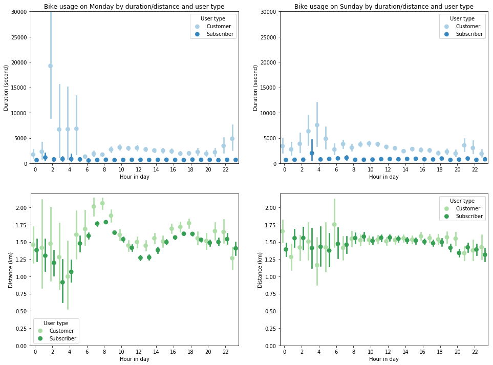

```python
#Creat dogde plot on Monday and Sunday for duration and distance with user type
fig, ax = plt.subplots(ncols = 2, figsize = [16,12])
xtick=[0,2,4,6,8,10,12,14,16,18,20,22]
label=['{}'.format(x) for x in xtick]

plt.subplot(2,2,1)
sb.pointplot(data = df[df['weekday']=='Monday'], x = 'hour', y = 'duration_sec', hue = 'user_type',
             palette = 'Blues', linestyles = '', dodge = 0.4)
plt.xticks(xtick, labels =label)
plt.xlabel('Hour in day')
plt.ylabel('Duration (second)')
plt.title('Bike usage on Monday by duration/distance and user type')
plt.legend(title = 'User type')
plt.ylim(0,30000)

plt.subplot(2,2,2)
sb.pointplot(data = df[df['weekday']=='Sunday'], x = 'hour', y = 'duration_sec', hue = 'user_type',
             palette = 'Blues', linestyles = '', dodge = 0.4)
plt.xticks(xtick, labels =label)
plt.xlabel('Hour in day')
plt.ylabel('Duration (second)')
plt.title('Bike usage on Sunday by duration/distance and user type')
plt.legend(title = 'User type')
plt.ylim(0,30000)

plt.subplot(2,2,3)
sb.pointplot(data = df[df['weekday']=='Monday'], x = 'hour', y = 'distance', hue = 'user_type',
             palette = 'Greens', linestyles = '', dodge = 0.4)
plt.xticks(xtick, labels =label)
plt.xlabel('Hour in day')
plt.ylabel('Distance (km)')
plt.legend(title = 'User type')
plt.ylim(0,2.2)

plt.subplot(2,2,4)
sb.pointplot(data = df[df['weekday']=='Sunday'], x = 'hour', y = 'distance', hue = 'user_type',
             palette = 'Greens', linestyles = '', dodge = 0.4)
plt.xticks(xtick,labels =label)
plt.xlabel('Hour in day')
plt.ylabel('Distance (km)')
plt.legend(title = 'User type')
plt.ylim(0,2.2)
plt.show();
```

Now, let's see how these factor differ in member gender variable.

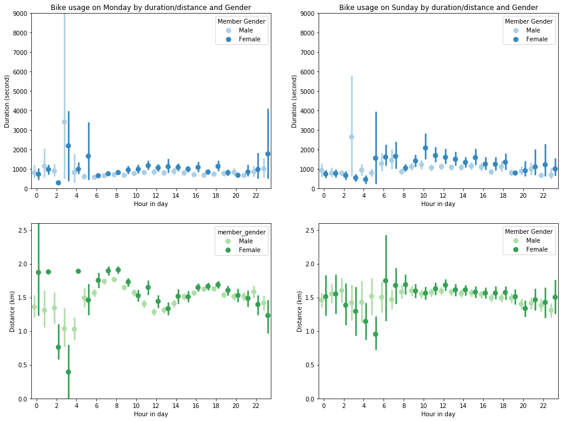

```python
#Creat dogde plot on Monday and Sunday for duration and distance with member gender
fig, ax = plt.subplots(ncols = 2, figsize = [16,12])

plt.subplot(2,2,1)
sb.pointplot(data = df.query('weekday =="Monday" & member_gender!= "Other"'), x = 'hour', y = 'duration_sec', hue = 'member_gender',
             palette = 'Blues', linestyles = '', dodge = 0.4)
plt.xticks(xtick, labels =label)
plt.xlabel('Hour in day')
plt.ylabel('Duration (second)')
plt.title('Bike usage on Monday by duration/distance and Gender')
plt.legend(title = 'Member Gender')
plt.ylim(0,9000)

plt.subplot(2,2,2)
sb.pointplot(data = df.query('weekday =="Sunday" & member_gender!= "Other"'), x = 'hour', y = 'duration_sec', hue = 'member_gender',
             palette = 'Blues', linestyles = '', dodge = 0.4)
plt.xticks(xtick, labels =label)
plt.xlabel('Hour in day')
plt.ylabel('Duration (second)')
plt.title('Bike usage on Sunday by duration/distance and Gender')
plt.legend(title = 'Member Gender')
plt.ylim(0,9000)

plt.subplot(2,2,3)
sb.pointplot(data = df.query('weekday =="Monday" & member_gender!= "Other"'), x = 'hour', y = 'distance', hue = 'member_gender',
             palette = 'Greens', linestyles = '', dodge = 0.4)
plt.xticks(xtick, labels =label)
plt.xlabel('Hour in day')
plt.ylabel('Distance (km)')
plt.ylim(0,2.6)

plt.subplot(2,2,4)
sb.pointplot(data = df.query('weekday =="Sunday" & member_gender!= "Other"'), x = 'hour', y = 'distance', hue = 'member_gender',
             palette = 'Greens', linestyles = '', dodge = 0.4)
plt.xticks(xtick,labels =label)
plt.xlabel('Hour in day')
plt.ylabel('Distance (km)')
plt.legend(title = 'Member Gender')
plt.ylim(0,2.6)
plt.show();
```

I will move on to analysize on member birth year.

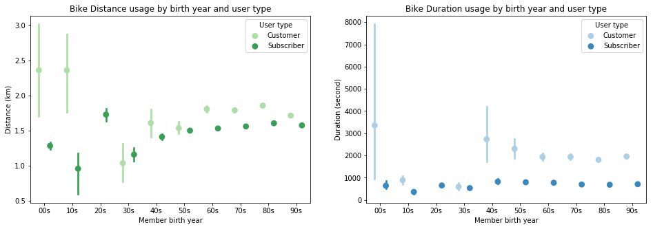

```python
##Creat dogde plot on birth year for duration and distance with user type
plt.figure(figsize = [16, 5])
plt.subplot(1,2,1)
sb.pointplot(data = df_year, x = 'year_cut', y = 'distance',linestyles = '', hue = 'user_type',
             palette = 'Greens', dodge = 0.4)
plt.xlabel('Member birth year')
plt.ylabel('Distance (km)')
plt.legend(title = 'User type')
plt.title('Bike Distance usage by birth year and user type')

plt.subplot(1,2,2)
sb.pointplot(data = df_year, x = 'year_cut', y = 'duration_sec',linestyles = '', hue = 'user_type',
             palette = 'Blues', dodge = 0.4)
plt.xlabel('Member birth year')
plt.ylabel('Duration (second)')
plt.legend(title = 'User type')
plt.title('Bike Duration usage by birth year and user type');
```

Let's look at member gender.

```python
#Creat sub dataset which excludes Other value in member_gender column
df_year_gen=df_year[df_year.member_gender != 'Other']
```

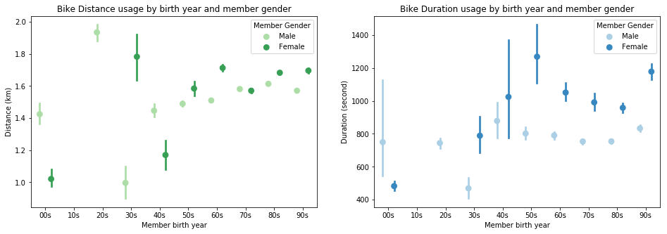

```python
#Creat dogde plot on birth year for duration and distance with member gender
plt.figure(figsize = [16, 5])

plt.subplot(1,2,1)
sb.pointplot(data = df_year_gen, x = 'year_cut', y = 'distance',linestyles = '',hue = 'member_gender',
             palette = 'Greens', dodge = 0.4)
plt.xlabel('Member birth year')
plt.ylabel('Distance (km)')
plt.legend(title = 'Member Gender')
plt.title('Bike Distance usage by birth year and member gender')

plt.subplot(1,2,2)
sb.pointplot(data = df_year_gen, x = 'year_cut', y = 'duration_sec',linestyles = '', hue = 'member_gender',
             palette = 'Blues', dodge = 0.4)
plt.xlabel('Member birth year')
plt.ylabel('Duration (second)')
plt.legend(title = 'Member Gender')
plt.title('Bike Duration usage by birth year and member gender');
```

### Were there any interesting or surprising interactions between features?

I don't see anything interesting.